# Statistical Learning Methods with R, Series 4

Michael Senn

29/03/2022

Load required libraries

```r
library(dplyr)
```

```r
library(tidyr)
library(ggplot2)
```

## Linear model for wage

```r
df_edu = read.csv("../data/EducationBis.txt", sep = "\t")
df_edu$Gender = factor(df_edu$Gender)
summary(df_edu)
```

```
##        ID          Education        Gender         Wage
##  Min.   :  1.0   Min.   : 5.00   female:198   Min.   :2047
##  1st Qu.:126.0   1st Qu.:12.00   male  :299   1st Qu.:4679
##  Median :251.0   Median :14.00                Median :5520
##  Mean   :250.5   Mean   :14.26                Mean   :5463
##  3rd Qu.:375.0   3rd Qu.:16.00                3rd Qu.:6319
##  Max.   :500.0   Max.   :22.00                Max.   :8454
```

```r
df_edu_male = df_edu %>% filter(Gender == "male")
df_edu_female = df_edu %>% filter(Gender == "female")

lm_male = lm(df_edu_male$Wage ~ df_edu_male$Education)
lm_female = lm(df_edu_female$Wage ~ df_edu_female$Education)
```

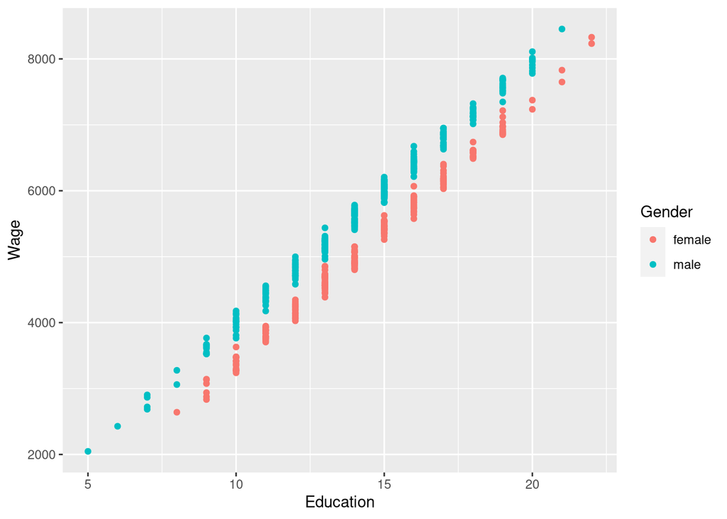

```r
ggplot(df_edu, aes(x = Education, y = Wage)) +
  geom_point(aes(color = Gender))
```

```r
summary(lm_male)
```

```
##
## Call:
## lm(formula = df_edu_male$Wage ~ df_edu_male$Education)
##
## Residuals:
##      Min       1Q   Median       3Q      Max
## -243.654  -74.152    6.096   70.923  279.797
##
## Coefficients:
##                       Estimate Std. Error t value Pr(>|t|)
## (Intercept)             24.199     27.937   0.866    0.387
## df_edu_male$Education  398.250      1.919 207.559   <2e-16 ***
## ---
## Signif. codes:  0 '***' 0.001 '**' 0.01 '*' 0.05 '.' 0.1 ' ' 1
##
## Residual standard error: 97.41 on 297 degrees of freedom
## Multiple R-squared:  0.9932, Adjusted R-squared:  0.9931
## F-statistic: 4.308e+04 on 1 and 297 DF,  p-value: < 2.2e-16
```

```r
summary(lm_female)
```

```
##
## Call:
## lm(formula = df_edu_female$Wage ~ df_edu_female$Education)
##
## Residuals:
##      Min       1Q   Median       3Q      Max
## -220.461  -78.869   -4.028   73.437  271.939
##
## Coefficients:
##                         Estimate Std. Error t value Pr(>|t|)
## (Intercept)              -563.61      37.50  -15.03   <2e-16 ***
## df_edu_female$Education   397.54       2.58  154.10   <2e-16 ***
## ---
## Signif. codes:  0 '***' 0.001 '**' 0.01 '*' 0.05 '.' 0.1 ' ' 1
##
## Residual standard error: 104.3 on 196 degrees of freedom
## Multiple R-squared:  0.9918, Adjusted R-squared:  0.9918
## F-statistic: 2.375e+04 on 1 and 196 DF,  p-value: < 2.2e-16
```

We see that both models have a nearly equivalent slope of slightly below 400, indicating that each year of education adds around 400 $currency to one’s monthly wage. Both slops are significantly above zero, indicating that there is a linear correlation between the two variables.

The differences in the intercept of 24 for the male and -560 for the female model indicates the constant difference between men and women with the same level of education.

## Combined model

We can also build a combined model which includes all possible predictors: ID, education, and gender.

```r
lm_combined = lm(df_edu$Wage ~ df_edu$ID + df_edu$Education + df_edu$Gender)
lm_combined
```

```
##
## Call:
## lm(formula = df_edu$Wage ~ df_edu$ID + df_edu$Education + df_edu$Gender)
##
## Coefficients:
##       (Intercept)          df_edu$ID   df_edu$Education  df_edu$Gendermale
##        -576.22317            0.02952          397.90661          597.94707
```

As expected the coefficient of the ID is nearly 0, indicating that the ID does not explain the wage at all. The correlations for education and gender being male then showcase the increase in wage which can be predicted by a person’s education respectively gender.

## Estimating computer performance

```r
library(corrplot)
df_pc = read.csv("../data/Computers.txt", sep="\t")
df_pc$vendor = factor(df_pc$vendor)
```

Clearly variables such as the model or vendor name are not applicable to predict performance in a linear model. Further, using PRP to predict itself would be an adventurous choice. Lastly ERP should not be used, as this field is the result of a linear prediction of PRP, based on the available predictor values, done by the paper’s authors.

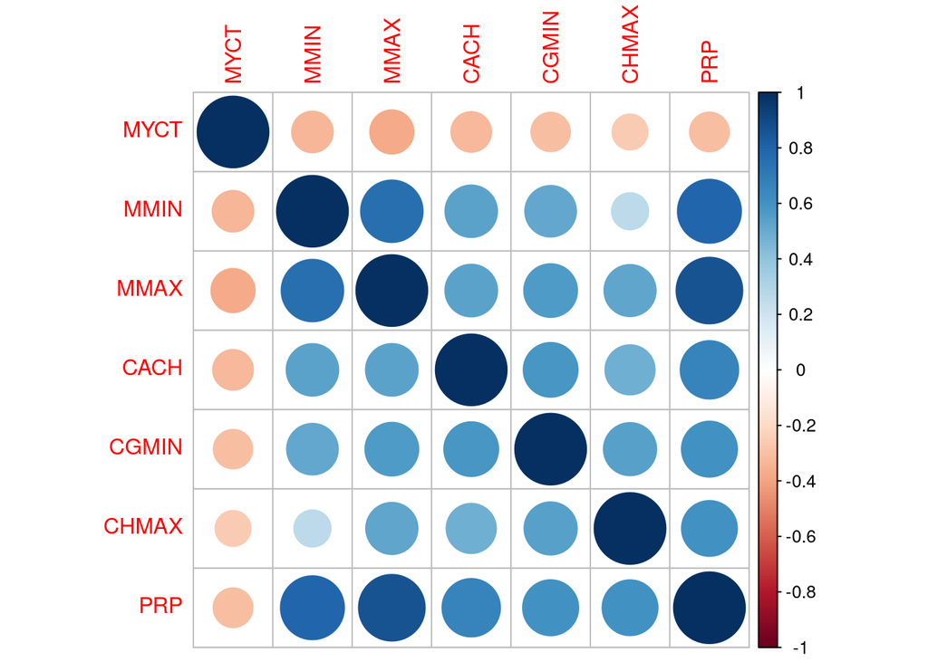

```r
df_pc.cor = cor(
  subset(
    df_pc[sapply(df_pc, is.numeric)],
    select = -c(ERP),
  )
)
corrplot(df_pc.cor)
```

Looking at the correlation plot reveals that MMAX (the maximum main memory) is likely to be the best (linear) predictor for the PRP value. We thus use that one to build our model.

```r
lm_pc = lm(PRP ~ MMAX, data = df_pc)
summary(lm_pc)
```

```
##
## Call:
## lm(formula = PRP ~ MMAX, data = df_pc)
##
## Residuals:
##     Min      1Q  Median      3Q     Max
## -230.76  -36.07    3.31   29.33  426.48
##
## Coefficients:
##               Estimate Std. Error t value Pr(>|t|)
## (Intercept) -3.400e+01  8.001e+00   -4.25 3.24e-05 ***
## MMAX         1.184e-02  4.816e-04   24.58  < 2e-16 ***
## ---
## Signif. codes:  0 '***' 0.001 '**' 0.01 '*' 0.05 '.' 0.1 ' ' 1
##
## Residual standard error: 81.45 on 207 degrees of freedom
## Multiple R-squared:  0.7448, Adjusted R-squared:  0.7435
## F-statistic: 604.1 on 1 and 207 DF,  p-value: < 2.2e-16
```